# Machine Learning-2 Customer Churn Project

### PROJECT OBJECTIVE:

- Based on the given users and items data of an e-commerce company, segment the similar user and items into suitable clusters
- Analyze the clusters and provide your insights to help the organization promote their business.

By Piyush Srivastava

### Import the required libraries and load the data:

Load the required libraries and read the dataset

Check the first few samples, shape, info of the data and try to familiarize yourself with different features

```python
# importing libraries

import pandas as pd
import numpy as np
import matplotlib.pyplot as plt
import seaborn as sns
import warnings
warnings.filterwarnings('ignore')

from sklearn.preprocessing import StandardScaler,LabelEncoder
from scipy import stats
from sklearn.cluster import KMeans
from scipy.stats import zscore
from scipy.spatial import distance
from scipy.cluster.hierarchy import linkage, dendrogram, fcluster
from sklearn.cluster import AgglomerativeClustering
from sklearn.decomposition import PCA
from sklearn.model_selection import train_test_split
from sklearn import preprocessing
from sklearn.preprocessing import Normalizer
```

```python
df=pd.read_csv('renttherunway.csv')
```

```python
df.info()
```

```
<class 'pandas.core.frame.DataFrame'>
RangeIndex: 192544 entries, 0 to 192543
Data columns (total 16 columns):
 #   Column          Non-Null Count   Dtype
---  ------          --------------   -----
 0   Unnamed: 0      192544 non-null  int64
 1   fit             192544 non-null  object
 2   user_id         192544 non-null  int64
 3   bust size       174133 non-null  object
 4   item_id         192544 non-null  int64
 5   weight          162562 non-null  object
 6   rating          192462 non-null  float64
 7   rented for      192534 non-null  object
 8   review_text     192482 non-null  object
 9   body type       177907 non-null  object
 10  review_summary  192199 non-null  object
 11  category        192544 non-null  object
 12  height          191867 non-null  object
 13  size            192544 non-null  int64
 14  age             191584 non-null  float64
 15  review_date     192544 non-null  object
dtypes: float64(2), int64(4), object(10)
memory usage: 23.5+ MB
```

```python
#exclude first column
df = df.iloc[: , 1:]
df.head()
```

|  | fit | user_id | bust size | item_id | weight | rating | rented for | review_text | body type | review_summary | category | height | size | age | review_date |
| --- | --- | --- | --- | --- | --- | --- | --- | --- | --- | --- | --- | --- | --- | --- | --- |
| 0 | fit | 420272 | 34d | 2260466 | 137lbs | 10.0 | vacation | An adorable romper! Belt and zipper were a lit... | hourglass | So many compliments! | romper | 5' 8" | 14 | 28.0 | April 20, 2016 |
| 1 | fit | 273551 | 34b | 153475 | 132lbs | 10.0 | other | I rented this dress for a photo shoot. The the... | straight & narrow | I felt so glamourous!!! | gown | 5' 6" | 12 | 36.0 | June 18, 2013 |
| 2 | fit | 360448 | NaN | 1063761 | NaN | 10.0 | party | This hugged in all the right places! It was a ... | NaN | It was a great time to celebrate the (almost) ... | sheath | 5' 4" | 4 | 116.0 | December 14, 2015 |
| 3 | fit | 909926 | 34c | 126335 | 135lbs | 8.0 | formal affair | I rented this for my company's black tie award... | pear | Dress arrived on time and in perfect condition. | dress | 5' 5" | 8 | 34.0 | February 12, 2014 |
| 4 | fit | 151944 | 34b | 616682 | 145lbs | 10.0 | wedding | I have always been petite in my upper body and... | athletic | Was in love with this dress !!! | gown | 5' 9" | 12 | 27.0 | September 26, 2016 |

- We have 192544 intances and 15 columns in the dataset.
- There are many missing values in the dataset.
- We have around 10 object type variables and rest all interger and float datatype variables.
1. Data cleansing and Exploratory data analysis: [ Score: 8 point ]

 Check if there are any duplicate records in the dataset? If any drop them.

 Drop the columns which you think redundant for the analysis.(Hint: drop columns like ‘id’, ‘review’)

 Check the column 'weight', Is there any presence of string data? If yes, remove the string data and convert to float. (Hint: 'weight' has the suffix as lbs)

 Check the unique categories for the column 'rented for' and group 'party: cocktail' category with 'party'.

 The column 'height' is in feet with a quotation mark, Convert to inches with float datatype.

 Check for missing values in each column of the dataset? If it exists, impute them with appropriate methods.

 Check the statistical summary for the numerical and categorical columns and write your findings.

 Is there outliers present in the column age? If yes treat them with appropriate method

 Check the distribution of the different categories in the column 'rented for' using appropriate plot.

```python
df = df.drop(columns= ['review_text','review_summary','user_id','review_date','item_id'])
```

```python
def check_duplicate(df):
    duplicate=df[df.duplicated()]
    return duplicate

duplicate=check_duplicate(df)
duplicate
```

|  | fit | bust size | weight | rating | rented for | body type | category | height | size | age |
| --- | --- | --- | --- | --- | --- | --- | --- | --- | --- | --- |
| 639 | fit | 34c | 135lbs | 10.0 | party | pear | sheath | 5' 4" | 12 | 34.0 |
| 2163 | fit | 34c | 120lbs | 10.0 | other | straight & narrow | dress | 5' 5" | 4 | 22.0 |
| 2253 | fit | 34dd | 165lbs | 8.0 | work | hourglass | dress | 5' 6" | 20 | 40.0 |
| 2747 | fit | 34d | 130lbs | 8.0 | everyday | full bust | dress | 5' 8" | 8 | 45.0 |
| 2870 | fit | 34c | 125lbs | 10.0 | work | full bust | dress | 5' 3" | 8 | 31.0 |
| ... | ... | ... | ... | ... | ... | ... | ... | ... | ... | ... |
| 192498 | fit | 32d | 125lbs | 10.0 | work | pear | dress | 5' 4" | 8 | 38.0 |
| 192521 | small | 34c | 125lbs | 10.0 | party | full bust | dress | 5' 3" | 12 | 31.0 |
| 192527 | fit | 34b | NaN | 10.0 | wedding | hourglass | dress | 5' 7" | 8 | 30.0 |
| 192530 | fit | 32c | 135lbs | 10.0 | work | pear | dress | 5' 8" | 8 | 32.0 |
| 192533 | fit | 34d | NaN | 8.0 | everyday | athletic | top | 6' 0" | 8 | 32.0 |

8809 rows × 10 columns

```python
#Removing missing values
df.dropna(how = 'any', inplace = True)
```

```python
# def duplicates(df):
#     duplicatevalue=df.duplicated().sum().any()
#     if duplicatevalue:
#         df=df.dropduplicates(keep='first', inplace=True)
#         print('Only original values have been retained in dataframe')
#     else:
#         print('No duplicates')
#     return
# duplicates(df)
```

#### Check the column 'weight', Is there any presence of string data? If yes, remove the string data and convert to float. (Hint: 'weight' has the suffix as lbs)

```python
# To remove lbs from column weight, converting to numeric dtype
def weightcol(df,colname):
    missingvalues=(df[colname].isnull()| df[colname].isna()).sum().any()
    if (str(df[colname].dtypes)=='object'):
        df[colname]=df[colname].str.replace('lbs','')
        df.loc[df[colname].notnull(),colname]=df.loc[df[colname].notnull(),colname].apply(int)

    if(missingvalues==False):
        print('No mising values')
    elif(missingvalues==True):
        df[colname]=df[colname].fillna(df[colname].median())
    return
weightcol(df, 'weight')
df.sample(n=5)
```

```
No mising values
```

|  | fit | bust size | weight | rating | rented for | body type | category | height | size | age |
| --- | --- | --- | --- | --- | --- | --- | --- | --- | --- | --- |
| 126732 | fit | 36c | 155 | 4.0 | party | pear | shirtdress | 5' 4" | 20 | 38.0 |
| 52514 | fit | 34d | 132 | 10.0 | party | full bust | dress | 5' 5" | 12 | 41.0 |
| 178669 | small | 34ddd/e | 136 | 10.0 | formal affair | full bust | dress | 5' 6" | 16 | 53.0 |
| 175192 | fit | 32d | 130 | 10.0 | everyday | athletic | dress | 5' 5" | 8 | 31.0 |
| 169035 | fit | 34dd | 155 | 10.0 | everyday | full bust | top | 5' 6" | 14 | 33.0 |

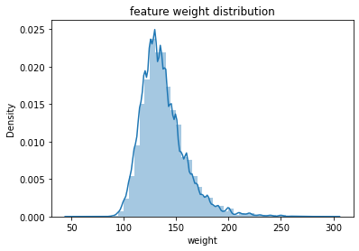

```python
sns.distplot(df['weight'])
plt.title('feature weight distribution')
plt.show()
```

```python
import re
r = re.compile(r".*([a-z])")
def get_cup(el):
    m = r.match(el)
    if m == None:
        return float('NaN')
    else:
        return str(m.group(1))
```

```python
df["bust size"] = df["bust size"].astype(str)
df["cup_size"] = df["bust size"].apply(get_cup)
```

```python
r = re.compile(r"([0-9]{2})([a-z])")
def Rib_Cage(el):
    m = r.match(el)
    if m == None:
        return float('NaN')
    else:
        return m.group(1)
```

```python
df["Rib_Cage"] = df["bust size"].apply(Rib_Cage)
```

```python
df = df.drop(columns="bust size", axis = 1)
df.head(2)
```

|  | fit | weight | rating | rented for | body type | category | height | size | age | cup_size | Rib_Cage |
| --- | --- | --- | --- | --- | --- | --- | --- | --- | --- | --- | --- |
| 0 | fit | 137 | 10.0 | vacation | hourglass | romper | 5' 8" | 14 | 28.0 | d | 34 |
| 1 | fit | 132 | 10.0 | other | straight & narrow | gown | 5' 6" | 12 | 36.0 | b | 34 |

#### Check the unique categories for the column 'rented for' and group 'party: cocktail' category with 'party'

```python
# Replacing party cocktail with party & unique categories

df['rented for']=df['rented for'].str.replace('party: cocktail','party')
df['rented for'].unique()
```

```
array(['vacation', 'other', 'formal affair', 'wedding', 'date',
       'everyday', 'party', 'work'], dtype=object)
```

```python
df['rented for'].value_counts()
```

```
wedding          42622
formal affair    30496
party            27199
everyday         13263
work             12124
other            11510
date              5929
vacation          3238
Name: rented for, dtype: int64
```

#### 'height' is in feet with a quotation mark, Convert to inches with float datatype

```python
import re
r = re.compile(r"([0-9]+)\' ([0-9])\"")
def get_inches(el):
    m = r.match(el)
    if m == None:
        return float('NaN')
    else:
        return int(m.group(1))*12 + float(m.group(2))
```

```python
df['height'] = df['height'].astype(str)
##df['height'] = df['height'].str.replace('','').astype(float)
df['height'] = df['height'].apply(get_inches)

df.head(2)
```

|  | fit | weight | rating | rented for | body type | category | height | size | age | cup_size | Rib_Cage |
| --- | --- | --- | --- | --- | --- | --- | --- | --- | --- | --- | --- |
| 0 | fit | 137 | 10.0 | vacation | hourglass | romper | 68.0 | 14 | 28.0 | d | 34 |
| 1 | fit | 132 | 10.0 | other | straight & narrow | gown | 66.0 | 12 | 36.0 | b | 34 |

```python
# replacing null values by medianin col height
df['height']=df['height'].replace(0, df['height'].median())
```

#### Check for missing values in each column of the dataset? If it exists, impute them with appropriate methods.

```python
df.isna().sum()
df = df.dropna()
```

```python
## Checking for missing values:
def missingvalues(df):
    missingvalues=(df.isnull() | df.isna()).sum().any()
    if missingvalues==False:
        print('0 Missing values')
    elif missingvalues==True:
        missingcol=df.columns[df.isnull().mean()!=0]
        percentage_of_misingvalues=df[missingcol].isnull().sum()/len(df)*100
        print('Display col with null values and dtypes\n',missingcol,missingcol.dtype)
        print('Missing rows\n',df[missingcol].isnull().sum())
        print('Missing row percentage\n',percentage_of_misingvalues)
    return
missingvalues(df)
```

```
0 Missing values
```

```python
df.shape
```

```
(137892, 11)
```

#### Check the statistical summary for the numerical and categorical columns and write your findings

```python
df.isnull().sum()
```

```
fit           0
weight        0
rating        0
rented for    0
body type     0
category      0
height        0
size          0
age           0
cup_size      0
Rib_Cage      0
dtype: int64
```

```python
df.describe()
```

|  | weight | rating | height | size | age |
| --- | --- | --- | --- | --- | --- |
| count | 137892.000000 | 137892.000000 | 137892.000000 | 137892.000000 | 137892.000000 |
| mean | 136.419669 | 9.086212 | 65.030966 | 11.242639 | 34.103385 |
| std | 21.145823 | 1.435057 | 2.401495 | 7.773166 | 8.108083 |
| min | 50.000000 | 2.000000 | 54.000000 | 0.000000 | 0.000000 |
| 25% | 122.000000 | 8.000000 | 63.000000 | 4.000000 | 29.000000 |
| 50% | 134.000000 | 10.000000 | 65.000000 | 8.000000 | 32.000000 |
| 75% | 145.000000 | 10.000000 | 67.000000 | 16.000000 | 37.000000 |
| max | 300.000000 | 10.000000 | 78.000000 | 58.000000 | 117.000000 |

```python
df.describe(include='O')
```

|  | fit | rented for | body type | category | cup_size | Rib_Cage |
| --- | --- | --- | --- | --- | --- | --- |
| count | 137892 | 137892 | 137892 | 137892 | 137892 | 137892 |
| unique | 3 | 8 | 7 | 68 | 10 | 11 |
| top | fit | wedding | hourglass | dress | d | 34 |
| freq | 101481 | 40295 | 41600 | 66585 | 42631 | 66373 |

##### Analysis of data

- Wedding wear has maximum purchases(40295)
- Hourglass figure is max selected
- company has all age group customers

#### Is there outliers present in the column age? If yes treat them with appropriate method

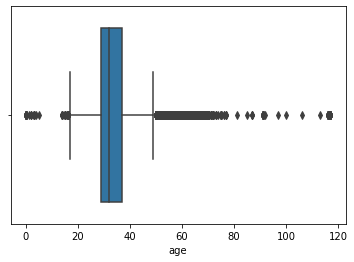

```python
# outliers:
sns.boxplot(x=df['age'])
```

```python
outliers = []
def detect_outliers_iqr(data):
    data = sorted(data)
    q1 = np.percentile(data, 25)
    q3 = np.percentile(data, 75)
    # print(q1, q3)
    IQR = q3-q1
    lowerbound = q1-(1.5*IQR)
    upperbound = q3+(1.5*IQR)

    for i in data:
        if (i<lowerbound or i>upperbound):
            outliers.append(i)
    return outliers# Driver code
age_outliers = detect_outliers_iqr(df['age'])
print("Outliers from IQR method: ", age_outliers)
```

```
Outliers from IQR method:  [0.0, 0.0, 0.0, 0.0, 0.0, 0.0, 0.0, 0.0, 0.0, 0.0, 0.0, 0.0, 0.0, 0.0, 0.0, 0.0, 0.0, 0.0, 0.0, 0.0, 1.0, 2.0, 2.0, 2.0, 3.0, 3.0, 3.0, 3.0, 3.0, 3.0, 3.0, 4.0, 5.0, 14.0, 14.0, 14.0, 14.0, 14.0, 14.0, 15.0, 15.0, 15.0, 15.0, 15.0, 15.0, 15.0, 15.0, 15.0, 16.0, 16.0, 16.0,…
```

```python
# Replace with median
median = np.median(df['age'])
for i in age_outliers:
    c = np.where(df['age']==i, median,df['age'])
```

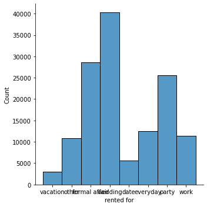

```python
# unique categories for the column 'rented for' and group 'party: cocktail' category with 'party
sns.displot(data=df,x='rented for')
```

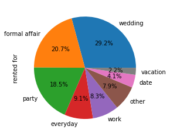

```python
df['rented for'].value_counts().plot(kind='pie',autopct='%.1f%%')
```

### Observations

- Vacation category has lowest selection by users
- People prefer the brand for Wedding and formal affairs the most
- This tells the company has lesser choices for casual funky wear for outings

### 3. Data Preparation for model building: [ Score: 1 point ]

 Encode the categorical variables in the dataset.

 Standardize the data, so that the values are within a particular range.

```python
categorical_cols_nominal = ['fit', "cup_size"]

from sklearn.preprocessing import LabelEncoder
# instantiate labelencoder object
le = LabelEncoder()

# apply le on categorical feature columns
df[categorical_cols_nominal] = df[categorical_cols_nominal].apply(lambda col: le.fit_transform(col))
```

```python
df_ = pd.get_dummies(data = df,columns = ['rented for', 'body type', 'category'])
df_.head(2)
```

|  | fit | weight | rating | height | size | age | cup_size | Rib_Cage | rented for_date | rented for_everyday | ... | category_tank | category_tee | category_tight | category_top | category_trench | category_trouser | category_trousers | category_tunic | category_turtleneck | category_vest |
| --- | --- | --- | --- | --- | --- | --- | --- | --- | --- | --- | --- | --- | --- | --- | --- | --- | --- | --- | --- | --- | --- |
| 0 | 0 | 137 | 10.0 | 68.0 | 14 | 28.0 | 3 | 34 | 0 | 0 | ... | 0 | 0 | 0 | 0 | 0 | 0 | 0 | 0 | 0 | 0 |
| 1 | 0 | 132 | 10.0 | 66.0 | 12 | 36.0 | 1 | 34 | 0 | 0 | ... | 0 | 0 | 0 | 0 | 0 | 0 | 0 | 0 | 0 | 0 |

2 rows × 91 columns

```python
df_cat = df.select_dtypes(include='object')
```

```python
df_sample = df_.sample(10000)   #10k samples is taken for Agglomertaive Clustering
```

```python
from sklearn.preprocessing import MinMaxScaler
scaler = MinMaxScaler()
data_rescaled = scaler.fit_transform(df_)
data_rescaled
```

```
array([[0.   , 0.348, 1.   , ..., 0.   , 0.   , 0.   ],
       [0.   , 0.328, 1.   , ..., 0.   , 0.   , 0.   ],
       [0.   , 0.34 , 0.75 , ..., 0.   , 0.   , 0.   ],
       ...,
       [0.   , 0.34 , 0.5  , ..., 0.   , 0.   , 0.   ],
       [0.   , 0.46 , 1.   , ..., 0.   , 0.   , 0.   ],
       [0.   , 0.42 , 1.   , ..., 0.   , 0.   , 0.   ]])
```

```python
#for sample rescaled
from sklearn.preprocessing import MinMaxScaler
scaler = MinMaxScaler()
data_rescaled_Sample = scaler.fit_transform(df_sample)
data_rescaled_Sample
```

```
array([[0.        , 0.39148936, 0.75      , ..., 0.        , 0.        ,
        0.        ],
       [0.        , 0.3106383 , 1.        , ..., 0.        , 0.        ,
        0.        ],
       [0.        , 0.29787234, 1.        , ..., 0.        , 0.        ,
        0.        ],
       ...,
       [0.        , 0.34042553, 1.        , ..., 0.        , 0.        ,
        0.        ],
       [0.5       , 0.4893617 , 1.        , ..., 0.        , 0.        ,
        0.        ],
       [1.        , 0.70212766, 1.        , ..., 0.        , 0.        ,
        0.        ]])
```

#### Principal Component Analysis and Clustering: [ Score: 8 point ]

 Apply PCA on the above dataset and determine the number of PCA components to be used so that 90-95% of the variance in data is explained by the same.

 Apply K-means clustering and segment the data. (You may use original data or PCA transformed data) a. Find the optimal K Value using elbow plot for Kmeans clustering.

b. Build a Kmeans clustering model using the obtained optimal K value from the elbow plot.

 Apply Agglomerative clustering and segment the data. (You may use original data or PCA transformed data) a. Find the optimal K Value using dendrogram for Agglomerative clustering.

b. Build a Agglomerative clustering model using the obtained optimal K value observed from dendrogram.

c. Compute silhoutte score for evaluating the quality of the Agglomerative clustering technique. (Hint: Take a sample of the dataset for agglomerative clustering to reduce the computational time)

```python
#95% of variance
from sklearn.decomposition import PCA
pca = PCA(n_components = 0.95)
pca.fit(data_rescaled)
reduced = pca.transform(data_rescaled)
len(reduced)
```

```
137892
```

```python
## Calculating covariance matrix
cov_matrix = np.cov(data_rescaled.T)
print('Covariance matrix','\n',cov_matrix)
```

```
Covariance matrix
 [[ 1.26548862e-01  4.50401229e-04 -1.55124516e-02 ...  2.44170818e-05
  -1.35725837e-05  3.37670022e-05]
 [ 4.50401229e-04  7.15433323e-03 -3.14190285e-04 ... -6.41484370e-06
  -1.80801310e-07 -1.51741438e-05]
 [-1.55124516e-02 -3.14190285e-04  3.21779416e-02 ... -4.18096534e-05
   1.90669373e-06  8.43007497e-07]
 ...
 [ 2.44170818e-05 -6.41484370e-06 -4.18096534e-05 ...  9.34646341e-04
  -1.49257925e-07 -1.34332132e-06]
 [-1.35725837e-05 -1.80801310e-07  1.90669373e-06 ... -1.49257925e-07
   1.59520853e-04 -2.29093559e-07]
 [ 3.37670022e-05 -1.51741438e-05  8.43007497e-07 ... -1.34332132e-06
  -2.29093559e-07  1.43385493e-03]]
```

```python
## Calculating eigen values and eigen vectors
eig_vals, eig_vecs = np.linalg.eig(cov_matrix)
print('Eigen vectors:','\n',eig_vecs)
print('\n')
print('Eigen values:','\n',eig_vals)
```

```
Eigen vectors:
 [[ 5.58857636e-02  3.54966482e-03 -5.12632275e-03 ... -2.00009448e-16
   9.07909219e-17 -4.75915193e-18]
 [-2.98747490e-03  2.81012388e-02  1.04854787e-02 ...  9.26710198e-17
   4.95838661e-16 -4.30103704e-15]
 [-2.05920335e-02 -8.68073975e-03  1.69962992e-02 ... -1.48253586e-16
   1.85877046e-16 -5.74470007e-17]
 ...
 [-3.07456001e-04  2.63260408e-04 -8.09689150e-04 ...  4.44874859e-02
   1.15017506e-01  5.73965997e-03]
 [-5.77852861e-05  1.47629432e-05 -1.35150084e-04 ...  4.44874859e-02
   1.15017506e-01  5.73965997e-03]
 [-5.23014494e-04  1.75229263e-04 -1.23872016e-03 ...  4.44874859e-02
   1.15017506e-01  5.73965997e-03]]


Eigen values:
 [ 3.84625501e-01  2.82096333e-01  2.53579998e-01  1.90693941e-01
  1.87757546e-01  1.41304538e-01  1.33500927e-01  1.27967257e-01
  9.95805673e-02  9.56970531e-02  8.47486494e-02  8.27324430e-02
  8.06697877e-02  4.63742617e-02  4.30038326e-02  3.22682910e-02
  2.91883837e-02  2.75529047e-02  2.46862169e-02  2.42065090e-02
  1.99797774e-02  1.93055772e-02  1.67650395e-02  1.30401669e-02
  1.07354358e-02  1.01108407e-02  8.42226097e-03  7.48767265e-03
  6.40015826e-03  5.47317510e-03  4.60430594e-03  4.50288464e-03
  3.99599011e-03  3.47882515e-03  3.13944541e-03  2.76999104e-03
  2.30064915e-03  1.69952464e-03  1.45207587e-03  1.33177508e-03
  1.21925253e-03  1.18620804e-03  1.11152571e-03  1.00217888e-03
  9.44514925e-04  8.04344317e-04  7.29879504e-04  6.88776816e-04
  6.49989277e-04  6.12297230e-04  5.75639673e-04  5.43563297e-04
  4.66620583e-04  3.87705731e-04  3.35679035e-04  2.88680666e-04
  2.71301532e-04  2.57482869e-04  2.30274984e-04  2.19886406e-04
  1.78671429e-04  1.62673930e-04  1.36460335e-04  1.30511918e-04
  1.02759402e-04  9.42439339e-05  9.42648764e-05  8.85129075e-05
  8.30194224e-05  7.97629409e-05  7.96636130e-05  7.44992855e-05
  7.24880947e-05  7.25088829e-05  5.23468551e-05  5.07596289e-05
  4.41224825e-05  3.68492318e-05  2.22772943e-05  2.17538850e-05
  3.06215162e-05  2.89840859e-05  2.90021886e-05  2.89982538e-05
  7.67098234e-06  7.25037234e-06  7.25148280e-06  7.25201725e-06
  4.47620607e-17 -2.44273271e-17  1.02559293e-16]
```

```python
total = sum(eig_vals)
var_exp = [ (i/total)*100  for i in sorted(eig_vals,reverse=True)]
cum_var_exp = np.cumsum(var_exp)
print('Variance Explained: ',var_exp)
print('Cummulative Variance Explained: ',cum_var_exp)
```

```
Variance Explained:  [15.181098447562762, 11.134290854388098, 10.00875631270214, 7.52665510581319, 7.410756116161203, 5.577264383968294, 5.269257259937989, 5.050844314886945, 3.9304268468981176, 3.777145249894334, 3.34501375015104, 3.265434450333199, 3.184021823885215, 1.830383660321386, 1.697353438…
Cummulative Variance Explained:  [ 15.18109845  26.3153893   36.32414561  43.85080072  51.26155684
  56.83882122  62.10807848  67.1589228   71.08934964  74.86649489
  78.21150864  81.47694309  84.66096492  86.49134858  88.18870202
  89.46232558  90.61438577  91.7018939   92.67625438  93.63168088
  94.42027905  95.18226667  95.84397972  96.35867274  96.78239843
  97.18147147  97.51389658  97.80943365  98.06204673  98.27807196
  98.45980307  98.63753111  98.79525211  98.93256071  99.05647404
  99.16580509  99.25661129  99.32369122  99.38100439  99.43356931
  99.48169298  99.5285124   99.57238411  99.61193993  99.64921976
  99.68096709  99.7097753   99.73696119  99.76261615  99.78678341
  99.8095038   99.83095815  99.84937558  99.86467825  99.87792744
  99.88932162  99.90002984  99.91019264  99.91928155  99.92796043
  99.93501256  99.94143327  99.94681933  99.95197061  99.95602651
  99.95974713  99.96346692  99.96696051  99.97023727  99.9733855
  99.9765298   99.97947028  99.98233219  99.98519328  99.9872594
  99.98926288  99.99100438  99.99245881  99.99366744  99.99481215
  99.99595671  99.9971007   99.99797998  99.99883861  99.99914138
  99.99942761  99.99971383 100.         100.         100.
 100.        ]
```

```python
# plt.bar(range(15),var_exp, align='center',color='lightgreen',edgecolor='black',label='Indiviual Explained Varinace')
# plt.step(range(15), cum_var_exp, where='mid',color='red',label='Cummulative explained Variance')
# plt.legend(loc = 'best')
# plt.ylabel('Explained Variance Ratio')
# plt.xlabel('Principal Components')
# plt.tight_layout()
# plt.show()
```

```python
pca=PCA(n_components = 10)
pca.fit(data_rescaled)
```

```
PCA(n_components=10)
```

```python
data_pca = pca.transform(data_rescaled)
data_pca = pd.DataFrame(data_pca,columns=['PC1','PC2','PC3','PC4','PC5','PC6','PC7','PC8','PC9','PC10'])
data_pca.head()
```

|  | PC1 | PC2 | PC3 | PC4 | PC5 | PC6 | PC7 | PC8 | PC9 | PC10 |
| --- | --- | --- | --- | --- | --- | --- | --- | --- | --- | --- |
| 0 | 0.199667 | 0.729126 | 0.029152 | 0.403882 | -0.236974 | -0.272365 | -0.076592 | -0.227796 | 0.048000 | -0.088808 |
| 1 | 0.700361 | -0.074204 | -0.101489 | 0.047799 | 0.347169 | -0.154128 | 0.053607 | -0.291899 | 0.532543 | 0.643763 |
| 2 | -0.075902 | 0.007530 | -0.421999 | -0.854215 | 0.420224 | 0.032276 | 0.630654 | -0.343685 | -0.494115 | -0.192065 |
| 3 | 0.662496 | -0.882915 | 0.683416 | 0.119501 | -0.461935 | 0.282305 | -0.075042 | -0.152718 | 0.288626 | -0.150640 |
| 4 | -0.510444 | -0.596955 | -0.347446 | -0.253575 | -0.513876 | -0.202388 | -0.104624 | -0.193633 | -0.045451 | -0.059100 |

```python
from sklearn.decomposition import PCA
pca = PCA(n_components = 0.95)
pca.fit(data_rescaled)
reduced = pca.transform(data_rescaled)
len(reduced)
```

```
137892
```

## K- Means

```python
cluster_range = range(1,15)
cluster_errors = []

for num_clusters in cluster_range:

    clusters = KMeans(num_clusters, n_init=10)
    clusters.fit(data_pca)

    labels = clusters.labels_
    centroids = clusters.cluster_centers_

    cluster_errors.append(clusters.inertia_)

clusters_df = pd.DataFrame({'num_clusters':cluster_range,
                           'cluster_errors':cluster_errors})

clusters_df
```

|  | num_clusters | cluster_errors |
| --- | --- | --- |
| 0 | 1 | 261552.151986 |
| 1 | 2 | 217090.361389 |
| 2 | 3 | 193256.223633 |
| 3 | 4 | 171698.299623 |
| 4 | 5 | 157238.440643 |
| 5 | 6 | 146376.551759 |
| 6 | 7 | 136407.612090 |
| 7 | 8 | 129282.075994 |
| 8 | 9 | 120061.431769 |
| 9 | 10 | 114547.283679 |
| 10 | 11 | 109244.085156 |
| 11 | 12 | 103622.627566 |
| 12 | 13 | 101514.859500 |
| 13 | 14 | 95288.598708 |

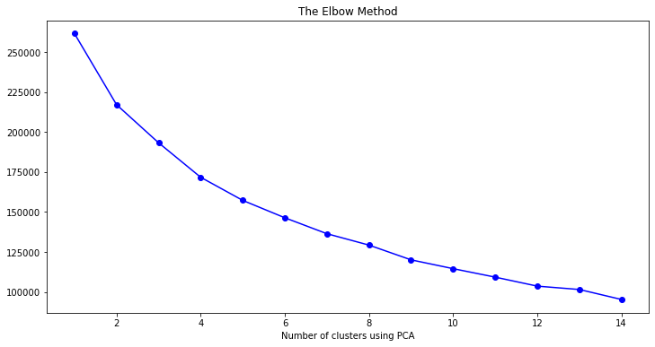

```python
## Elbow method
plt.figure(figsize=[12,6])
plt.title('The Elbow Method')
plt.xlabel('Number of clusters using PCA')
plt.plot(clusters_df['num_clusters'],clusters_df['cluster_errors'],marker='o',color='b')
plt.show()
```

```python
## Fit the KMeans clustering model using the obtained optimal K
kmeans = KMeans(n_clusters=6, n_init=15, random_state=2345)
kmeans.fit(data_pca)
```

```
KMeans(n_clusters=6, n_init=15, random_state=2345)
```

```python
## obtained labels from kmeans clustering
kmeans.labels_
```

```
array([5, 4, 0, ..., 0, 3, 3])
```

```python
## Creating a new dataframe only for labels and converting it into categorical variables.
df_labels = pd.DataFrame(kmeans.labels_, columns=list(['Labels']))
df_labels.head(5)
```

|  | Labels |
| --- | --- |
| 0 | 5 |
| 1 | 4 |
| 2 | 0 |
| 3 | 3 |
| 4 | 1 |

```python
df_labels['Labels'] = df_labels['Labels'].astype('category')
```

```python
## joining the label dataframe with unscaled initial dataframe.(df)

df_kmeans = df.join(df_labels)

df_kmeans.head()
```

|  | fit | weight | rating | rented for | body type | category | height | size | age | cup_size | Rib_Cage | Labels |
| --- | --- | --- | --- | --- | --- | --- | --- | --- | --- | --- | --- | --- |
| 0 | 0 | 137 | 10.0 | vacation | hourglass | romper | 68.0 | 14 | 28.0 | 3 | 34 | 5 |
| 1 | 0 | 132 | 10.0 | other | straight & narrow | gown | 66.0 | 12 | 36.0 | 1 | 34 | 4 |
| 3 | 0 | 135 | 8.0 | formal affair | pear | dress | 65.0 | 8 | 34.0 | 2 | 34 | 3 |
| 4 | 0 | 145 | 10.0 | wedding | athletic | gown | 69.0 | 12 | 27.0 | 1 | 34 | 1 |
| 5 | 0 | 138 | 8.0 | date | athletic | dress | 68.0 | 8 | 45.0 | 1 | 32 | 5 |

```python
df_kmeans['Labels'].value_counts()
```

```
5    22693
0    17541
3    16480
4    16309
1    13843
2    11896
Name: Labels, dtype: int64
```

#### Apply Agglomerative clustering and segment the data. (You may use original data or PCA transformed data)

a. Find the optimal K Value using dendrogram for Agglomerative clustering.

b. Build a Agglomerative clustering model using the obtained optimal K value observed from dendrogram.

c. Compute silhoutte score for evaluating the quality of the Agglomerative clustering technique.

(Hint: Take a sample of the dataset for agglomerative clustering to reduce the computational time)

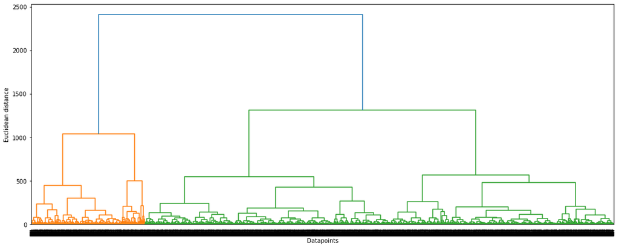

```python
plt.figure(figsize=[18,7])
merg = linkage(df_sample, method='ward')
dendrogram(merg, leaf_rotation=90)
plt.xlabel('Datapoints')
plt.ylabel('Euclidean distance')
plt.show()
```

```python
## Building hierarchical clustering model using the optimal clusters as 4
hie_cluster = AgglomerativeClustering(n_clusters=4, affinity='euclidean',
                                     linkage='ward')
hie_cluster_model = hie_cluster.fit(df_sample)
```

```python
## Creating a dataframe of the labels
df_label1 = pd.DataFrame(hie_cluster_model.labels_,columns=['Labels'])
df_label1.head(5)
```

|  | Labels |
| --- | --- |
| 0 | 2 |
| 1 | 0 |
| 2 | 0 |
| 3 | 0 |
| 4 | 2 |

```python
## joining the label dataframe with unscaled initial dataframe.(df_)

df_hier = df_.join(df_label1)
df_hier.head()
```

|  | fit | weight | rating | height | size | age | cup_size | Rib_Cage | rented for_date | rented for_everyday | ... | category_tee | category_tight | category_top | category_trench | category_trouser | category_trousers | category_tunic | category_turtleneck | category_vest | Labels |
| --- | --- | --- | --- | --- | --- | --- | --- | --- | --- | --- | --- | --- | --- | --- | --- | --- | --- | --- | --- | --- | --- |
| 0 | 0 | 137 | 10.0 | 68.0 | 14 | 28.0 | 3 | 34 | 0 | 0 | ... | 0 | 0 | 0 | 0 | 0 | 0 | 0 | 0 | 0 | 2.0 |
| 1 | 0 | 132 | 10.0 | 66.0 | 12 | 36.0 | 1 | 34 | 0 | 0 | ... | 0 | 0 | 0 | 0 | 0 | 0 | 0 | 0 | 0 | 0.0 |
| 3 | 0 | 135 | 8.0 | 65.0 | 8 | 34.0 | 2 | 34 | 0 | 0 | ... | 0 | 0 | 0 | 0 | 0 | 0 | 0 | 0 | 0 | 0.0 |
| 4 | 0 | 145 | 10.0 | 69.0 | 12 | 27.0 | 1 | 34 | 0 | 0 | ... | 0 | 0 | 0 | 0 | 0 | 0 | 0 | 0 | 0 | 2.0 |
| 5 | 0 | 138 | 8.0 | 68.0 | 8 | 45.0 | 1 | 32 | 1 | 0 | ... | 0 | 0 | 0 | 0 | 0 | 0 | 0 | 0 | 0 | 0.0 |

5 rows × 92 columns

```python
from sklearn.metrics import silhouette_score
for i in range(2,15):
    hier = AgglomerativeClustering(n_clusters=i)
    hier = hier.fit(data_rescaled_Sample)
    labels = hier.fit_predict(data_rescaled_Sample)
    print(i,silhouette_score(data_rescaled_Sample,labels))
```

```
2 0.11572914207319614
3 0.09576077400569098
4 0.0914214767879782
5 0.10633989589254834
6 0.11898573592202535
7 0.10371290032436514
8 0.11451390990330615
9 0.12740094513633823
10 0.12725965326857705
11 0.13778532026171023
12 0.1485063211783389
13 0.1560342677016165
14 0.14632685678969606
```